# Activity Prediction

Stefan Faußer

11.05.2016

# Summary

In this document, activities are predicted from accelerometers on the belt, forearm, arm, and dumbell of six participants. The data is from the Weight Lifting Exercises dataset from http://groupware.les.inf.puc-rio.br/har. The participipants were asked to perform five different fashions, ten repetitions, of the Unilateral Dumbbell Biceps Curl. These are: According to specification (A), throwing elbows to front (B), lifting halfway (C), lowering halfway (D), throwing hips to front (E).

Summarized, out of the evaluated models, the random forests performed best with an **out-of-sample accuracy** of more than $0.99$, followed by stochastic gradient boosting ($0.96$).

# Preprocessing

In this section, the data preprocessing steps are described.

```r
library(caret, quietly=TRUE)
library(corrplot, quietly=TRUE)
library(doMC, quietly=TRUE)
registerDoMC(cores = 6) # allow parallel processing with up to six cores
trainingFile <- "pml-training.csv"
trainData <- read.csv(trainingFile, na.strings = c("NA", ""))
```

**Predictor selection:** For reducing the complexity of the model, predictors are removed from the dataset according to the following critera:

- Irrelevant predictors. This includes: integer sequence (`X`), names (`user_name`), timestamps, windows, data columns: `1:7`.
- Predictors that have more than 90% of missing values (`NA`).
- Predictors with near zero variance.

```r
cols <- 1:7 # names, dates, timestamps
# get predictors that have more than 90% NAs
cols <- c(cols, which(colSums(is.na(trainData)) > nrow(trainData) * 0.9))
# get predictors with near zero variance
cols <- c(cols, nearZeroVar(trainData))
cols <- unique(cols)
trainData <- trainData[,-cols] # remove the predictors
print(sort(cols)) # outputs the removed predictors
```

```
##   [1]   1   2   3   4   5   6   7  12  13  14  15  16  17  18  19  20  21
##  [18]  22  23  24  25  26  27  28  29  30  31  32  33  34  35  36  50  51
##  [35]  52  53  54  55  56  57  58  59  69  70  71  72  73  74  75  76  77
##  [52]  78  79  80  81  82  83  87  88  89  90  91  92  93  94  95  96  97
##  [69]  98  99 100 101 103 104 105 106 107 108 109 110 111 112 125 126 127
##  [86] 128 129 130 131 132 133 134 135 136 137 138 139 141 142 143 144 145
## [103] 146 147 148 149 150
```

## Collinearity

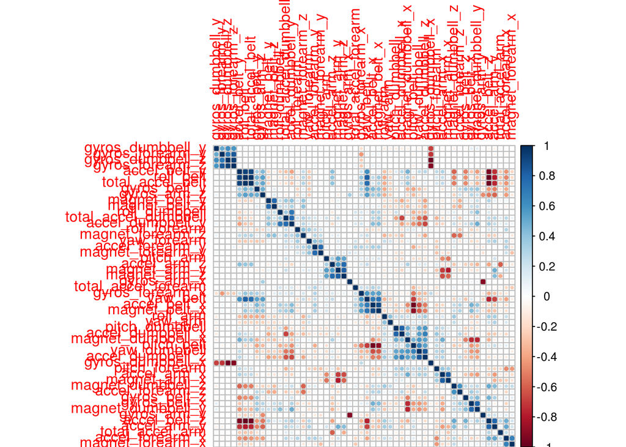

```r
corrs <- cor(trainData[,-ncol(trainData)])
corrplot(corrs, order = "hclust")
```

```r
cols <- findCorrelation(corrs, cutoff = 0.9)
trainData <- trainData[,-cols] # remove the predictors
print(sort(cols)) # outputs the removed predictors
```

```
## [1]  1  8  9 10 18 31 33
```

# Model building

- The training dataset (`pml-training.csv`) is splitted into training ($0.6$ of the data) and testing using stratified sampling.

```r
set.seed(107)
inTrain <- createDataPartition(y = trainData$classe, p = 0.6, list = FALSE)
training <- trainData[inTrain,]
testing <- trainData[-inTrain,]
```

**Random forests:**

```r
set.seed(107)
rfFit <- train(classe ~.,
               data = training,
               method = "rf",
               trControl = trainControl(method = "repeatedcv", number = 5, repeats = 3))
rfCmTrain <- confusionMatrix(data = predict(rfFit, training), training$classe)
rfCmTrain
```

```
## Confusion Matrix and Statistics
##
##           Reference
## Prediction    A    B    C    D    E
##          A 3348    0    0    0    0
##          B    0 2279    0    0    0
##          C    0    0 2054    0    0
##          D    0    0    0 1930    0
##          E    0    0    0    0 2165
##
## Overall Statistics
##
##                Accuracy : 1
##                  95% CI : (0.9997, 1)
##     No Information Rate : 0.2843
##     P-Value [Acc > NIR] : < 2.2e-16
##
##                   Kappa : 1
##  Mcnemar's Test P-Value : NA
##
## Statistics by Class:
##
##                      Class: A Class: B Class: C Class: D Class: E
## Sensitivity            1.0000   1.0000   1.0000   1.0000   1.0000
## Specificity            1.0000   1.0000   1.0000   1.0000   1.0000
## Pos Pred Value         1.0000   1.0000   1.0000   1.0000   1.0000
## Neg Pred Value         1.0000   1.0000   1.0000   1.0000   1.0000
## Prevalence             0.2843   0.1935   0.1744   0.1639   0.1838
## Detection Rate         0.2843   0.1935   0.1744   0.1639   0.1838
## Detection Prevalence   0.2843   0.1935   0.1744   0.1639   0.1838
## Balanced Accuracy      1.0000   1.0000   1.0000   1.0000   1.0000
```

```r
1 - as.vector(rfCmTrain$overall['Accuracy']) # in-sample error
```

```
## [1] 0
```

**Stochastic gradient boosting with decision trees:**

```r
set.seed(107)
gbmFit <- train(classe ~.,
                data = training,
                method = "gbm",
                verbose = FALSE,
                trControl = trainControl(method = "repeatedcv", number = 5, repeats = 3))
gbmCmTrain <- confusionMatrix(data = predict(gbmFit, training), training$classe)
gbmCmTrain
```

```
## Confusion Matrix and Statistics
##
##           Reference
## Prediction    A    B    C    D    E
##          A 3319   54    0    0    3
##          B   24 2174   56    4   13
##          C    5   46 1975   53   22
##          D    0    0   19 1860   23
##          E    0    5    4   13 2104
##
## Overall Statistics
##
##                Accuracy : 0.9708
##                  95% CI : (0.9676, 0.9738)
##     No Information Rate : 0.2843
##     P-Value [Acc > NIR] : < 2.2e-16
##
##                   Kappa : 0.963
##  Mcnemar's Test P-Value : NA
##
## Statistics by Class:
##
##                      Class: A Class: B Class: C Class: D Class: E
## Sensitivity            0.9913   0.9539   0.9615   0.9637   0.9718
## Specificity            0.9932   0.9898   0.9870   0.9957   0.9977
## Pos Pred Value         0.9831   0.9573   0.9400   0.9779   0.9897
## Neg Pred Value         0.9965   0.9890   0.9918   0.9929   0.9937
## Prevalence             0.2843   0.1935   0.1744   0.1639   0.1838
## Detection Rate         0.2818   0.1846   0.1677   0.1579   0.1787
## Detection Prevalence   0.2867   0.1928   0.1784   0.1615   0.1805
## Balanced Accuracy      0.9923   0.9719   0.9743   0.9797   0.9848
```

```r
1 - as.vector(gbmCmTrain$overall['Accuracy']) # in-sample error
```

```
## [1] 0.02921196
```

# Out-of-sample error and model selection

- The testing dataset (see above) is used for retrieving the **out-of-sample errors**.
- The **out-of-sample errors** are expected to be higher than the **in-sample errors** (training errors), see section *Model building and selection* above, because the models were trained with the training data and are, thus, biased towards the training data.
- The model with the lowest **out-of-sample error** is considered to be the final model.

```r
rfCmTest <- confusionMatrix(data = predict(rfFit, testing), testing$classe) # random forests
rfCmTest
```

```
## Confusion Matrix and Statistics
##
##           Reference
## Prediction    A    B    C    D    E
##          A 2228    6    0    0    0
##          B    3 1508   14    0    0
##          C    0    4 1347   15    3
##          D    0    0    7 1270    5
##          E    1    0    0    1 1434
##
## Overall Statistics
##
##                Accuracy : 0.9925
##                  95% CI : (0.9903, 0.9943)
##     No Information Rate : 0.2845
##     P-Value [Acc > NIR] : < 2.2e-16
##
##                   Kappa : 0.9905
##  Mcnemar's Test P-Value : NA
##
## Statistics by Class:
##
##                      Class: A Class: B Class: C Class: D Class: E
## Sensitivity            0.9982   0.9934   0.9846   0.9876   0.9945
## Specificity            0.9989   0.9973   0.9966   0.9982   0.9997
## Pos Pred Value         0.9973   0.9889   0.9839   0.9906   0.9986
## Neg Pred Value         0.9993   0.9984   0.9968   0.9976   0.9988
## Prevalence             0.2845   0.1935   0.1744   0.1639   0.1838
## Detection Rate         0.2840   0.1922   0.1717   0.1619   0.1828
## Detection Prevalence   0.2847   0.1944   0.1745   0.1634   0.1830
## Balanced Accuracy      0.9986   0.9954   0.9906   0.9929   0.9971
```

```r
1 - as.vector(rfCmTest$overall['Accuracy']) # out-of-sample error
```

```
## [1] 0.007519755
```

```r
gbmCmTest <- confusionMatrix(data = predict(gbmFit, testing), testing$classe) # stochastic gradient boosting
gbmCmTest
```

```
## Confusion Matrix and Statistics
##
##           Reference
## Prediction    A    B    C    D    E
##          A 2201   41    0    0    2
##          B   21 1435   50    7   23
##          C    4   34 1299   46   11
##          D    3    4   16 1228   18
##          E    3    4    3    5 1388
##
## Overall Statistics
##
##                Accuracy : 0.9624
##                  95% CI : (0.958, 0.9665)
##     No Information Rate : 0.2845
##     P-Value [Acc > NIR] : < 2.2e-16
##
##                   Kappa : 0.9524
##  Mcnemar's Test P-Value : 1.159e-08
##
## Statistics by Class:
##
##                      Class: A Class: B Class: C Class: D Class: E
## Sensitivity            0.9861   0.9453   0.9496   0.9549   0.9626
## Specificity            0.9923   0.9840   0.9853   0.9938   0.9977
## Pos Pred Value         0.9808   0.9342   0.9319   0.9677   0.9893
## Neg Pred Value         0.9945   0.9868   0.9893   0.9912   0.9916
## Prevalence             0.2845   0.1935   0.1744   0.1639   0.1838
## Detection Rate         0.2805   0.1829   0.1656   0.1565   0.1769
## Detection Prevalence   0.2860   0.1958   0.1777   0.1617   0.1788
## Balanced Accuracy      0.9892   0.9647   0.9674   0.9743   0.9801
```

```r
1 - as.vector(gbmCmTest$overall['Accuracy']) # out-of-sample error
```

```
## [1] 0.03759878
```